# MasterDoc

# logistic model

## model setup

Goal: Use the reference proteins to train a logistic model that predicts the probability of RNA binding for the remaining proteins ### comparison of positive and negative control - A significant difference between positive and negative controls is essential for the model to learn a meaningful separation - A Mann–Whitney U test is used to assess whether the positive and negative control groups perform significantly differently in the tests

```r
#check whether positive and negative control are reliable and whether they differ significantly
# Vector of column indices to test
cols_to_test <- c(2,4,5,6,7)

# Empty list to store test results
test_results <- list()

for (col in cols_to_test) {
  # Extract the column from both dataframes
  pos_values <- df_positive_control[[col]]
  neg_values <- df_negative_control[[col]]

  # Perform Wilcoxon Rank Sum test (Mann-Whitney U test)
  test <- wilcox.test(pos_values, neg_values)

  # Store the p-value with the column name as key
  test_results[[colnames(df_positive_control)[col]]] <- test$p.value
}

# Create a data frame to display p-values
test_results_df <- data.frame(
  Column = names(test_results),
  p_value = unlist(test_results)
)
```

### visualization of performence of reference proteins in tests

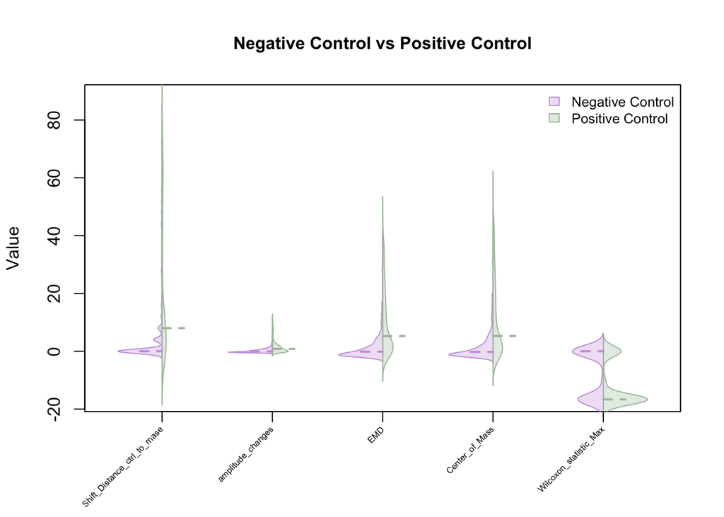

```r
# Load libraries
library(ggplot2)
library(dplyr)
library(tidyr)

# Example columns to test (analogous to cols_to_test)
cols_to_test <- c(2,4,5,6,7)
col_names <- colnames(df_positive_control)[cols_to_test]

n <- length(cols_to_test)
x_positions <- seq(1, by = 1, length.out = n)

# Determine range of y-axis values
all_values <- c()
for(i in seq_along(cols_to_test)) {
  col_idx <- cols_to_test[i]
  vals_neg <- as.numeric(df_negative_control[[col_idx]])
  vals_pos <- as.numeric(df_positive_control[[col_idx]])
  all_values <- c(all_values, vals_neg, vals_pos)
}

# Transparent fill colors
fill_neg <- adjustcolor("#c9a0dc", alpha.f = 0.3)
fill_pos <- adjustcolor("#A9C1A6", alpha.f = 0.3)

plot(NA,
     xlim = c(0.5, n + 0.5),
     ylim = range(all_values, na.rm = TRUE),
     xaxt = "n",
     xlab = "",
     ylab = "Value",
     main = "Negative Control vs Positive Control",
     cex.main = 1,
     cex.lab = 1
)

# Draw x-axis without labels
axis(1, at = x_positions, labels = FALSE, tick = TRUE)

# Draw rotated labels below the axis
text(x = x_positions, y = par("usr")[3] - 0.05 * diff(par("usr")[3:4]),
     labels = col_names,
     srt = 45,          # 45 degree angle
     adj = 1,           # right aligned
     xpd = TRUE,        # allow drawing outside plot region
     cex = 0.5)         # small font size

for(i in seq_along(cols_to_test)) {
  col_idx <- cols_to_test[i]
  x <- x_positions[i]

  vals_neg <- as.numeric(df_negative_control[[col_idx]])
  vals_pos <- as.numeric(df_positive_control[[col_idx]])

  if(sum(!is.na(vals_neg)) < 2 || sum(!is.na(vals_pos)) < 2) next

  dens_neg <- tryCatch(density(vals_neg, na.rm = TRUE), error = function(e) NULL)
  dens_pos <- tryCatch(density(vals_pos, na.rm = TRUE), error = function(e) NULL)
  if(is.null(dens_neg) || is.null(dens_pos)) next

  max_y <- max(c(dens_neg$y, dens_pos$y))
  scale_factor <- 0.4 / max_y

  # Left half (negative control) with transparent fill
  x_left <- x - dens_neg$y * scale_factor
  y_vals <- dens_neg$x
  polygon(c(x_left, rev(rep(x, length(x_left)))),
          c(y_vals, rev(y_vals)),
          col = fill_neg, border = "#c9a0dc")

  # Right half (positive control) with transparent fill
  x_right <- x + dens_pos$y * scale_factor
  y_vals2 <- dens_pos$x
  polygon(c(rep(x, length(x_right)), rev(x_right)),
          c(y_vals2, rev(y_vals2)),
          col = fill_pos, border = "#A9C1A6")

  # Median lines
  med_neg <- median(vals_neg, na.rm = TRUE)
  med_pos <- median(vals_pos, na.rm = TRUE)

  lines(c(x - 0.2, x), rep(med_neg, 2), col = "#c9a0dc", lty = 2, lwd = 2)
  lines(c(x, x + 0.2), rep(med_pos, 2), col = "#A9C1A6", lty = 2, lwd = 2)
}

legend("topright",
       legend = c("Negative Control", "Positive Control"),
       fill = c(fill_neg, fill_pos),    # Transparent fill colors in legend
       border = c("#c9a0dc", "#A9C1A6"),
       bty = "n",
       cex = 0.8)
```

### build logistic model

- logistic model based on all tests is created
- check for redundancy/multicollinearity using step()function

```r
# 1. Add labels to the datasets
df_positive_control$label <- 1  # Positive control group labeled as 1
df_negative_control$label <- 0  # Negative control group labeled as 0

# 2. Combine the datasets and keep the relevant columns (features + label)
df_all <- rbind(
  df_positive_control[, c("EMD", "Shift_Distance_ctrl_to_rnase", "amplitude_changes", "Center_of_Mass", "Wilcoxon_statistic_Max", "label")],
  df_negative_control[, c("EMD", "Shift_Distance_ctrl_to_rnase", "amplitude_changes", "Center_of_Mass", "Wilcoxon_statistic_Max", "label")]
)

# 3. Fit full logistic regression model with all predictors
full_model <- glm(label ~ EMD + Shift_Distance_ctrl_to_rnase + amplitude_changes + Center_of_Mass + Wilcoxon_statistic_Max,
                  data = df_all,
                  family = binomial)

# 4. Stepwise feature selection based on AIC
step_model <- step(full_model, direction = "both", trace = TRUE)
```

```
## Start:  AIC=1167.76
## label ~ EMD + Shift_Distance_ctrl_to_rnase + amplitude_changes +
##     Center_of_Mass + Wilcoxon_statistic_Max
##
##                                Df Deviance    AIC
## - Shift_Distance_ctrl_to_rnase  1   1157.2 1167.2
## <none>                              1155.8 1167.8
## - Wilcoxon_statistic_Max        1   1158.5 1168.5
## - Center_of_Mass                1   1172.7 1182.7
## - EMD                           1   1182.5 1192.5
## - amplitude_changes             1   1229.6 1239.6
##
## Step:  AIC=1167.17
## label ~ EMD + amplitude_changes + Center_of_Mass + Wilcoxon_statistic_Max
##
##                                Df Deviance    AIC
## <none>                              1157.2 1167.2
## - Wilcoxon_statistic_Max        1   1159.2 1167.2
## + Shift_Distance_ctrl_to_rnase  1   1155.8 1167.8
## - Center_of_Mass                1   1173.5 1181.5
## - EMD                           1   1182.6 1190.6
## - amplitude_changes             1   1235.1 1243.1
```

```r
# 5. Summary of the reduced model
summary(step_model)
```

```
##
## Call:
## glm(formula = label ~ EMD + amplitude_changes + Center_of_Mass +
##     Wilcoxon_statistic_Max, family = binomial, data = df_all)
##
## Coefficients:
##                         Estimate Std. Error z value Pr(>|z|)
## (Intercept)            -0.984683   0.113076  -8.708  < 2e-16 ***
## EMD                     0.528760   0.112480   4.701 2.59e-06 ***
## amplitude_changes       0.398652   0.057466   6.937 4.00e-12 ***
## Center_of_Mass         -0.365855   0.096292  -3.799 0.000145 ***
## Wilcoxon_statistic_Max -0.013501   0.009435  -1.431 0.152444
## ---
## Signif. codes:  0 '***' 0.001 '**' 0.01 '*' 0.05 '.' 0.1 ' ' 1
##
## (Dispersion parameter for binomial family taken to be 1)
##
##     Null deviance: 1524.9  on 1099  degrees of freedom
## Residual deviance: 1157.2  on 1095  degrees of freedom
## AIC: 1167.2
##
## Number of Fisher Scoring iterations: 5
```

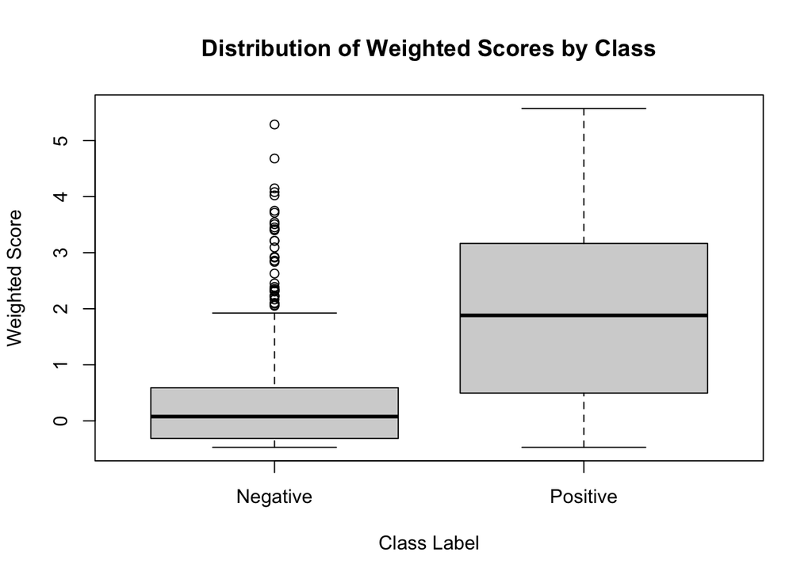

```r
# 6. Create a weighted score using the selected model's coefficients
coeffs <- coef(step_model)[-1]  # exclude intercept
selected_features <- names(coeffs)
df_all$weighted_score <- rowSums(sweep(df_all[, selected_features], 2, coeffs, FUN = "*"))

# 7. Visualize weighted score by class
boxplot(weighted_score ~ label, data = df_all,
        names = c("Negative", "Positive"),
        xlab = "Class Label", ylab = "Weighted Score",
        main = "Distribution of Weighted Scores by Class")
```

output: - step()functionn did remove Shift Distance -> redundant - The regression estimate represents the influence of a given predictor on the log-odds of RNA binding. A higher estimate increases the predicted probability. - The Pr(>|z|) value indicates whether a test is statistically significant, the lower values (e.g. p<0.05), the more significant the predictor’s contribution to the model (+ the less likely is the relation coincidental) -> Wilcoxon statistic is does not contribute significantly to the model

## visulaization of the tests’ influence on the final probability score

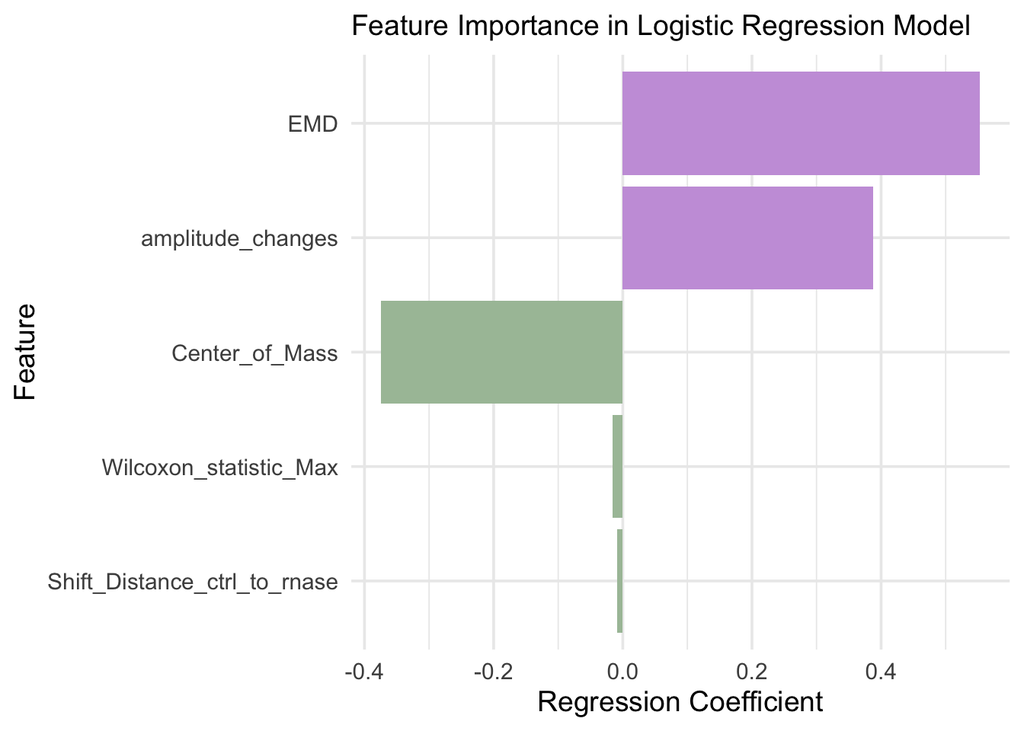

```r
logistic_model <- glm(label ~ EMD + Shift_Distance_ctrl_to_rnase + amplitude_changes + Center_of_Mass + Wilcoxon_statistic_Max,
                      data = df_all,
                      family = "binomial")


# Check if the model is a logistic regression (binomial family)
if (inherits(logistic_model, "glm") && family(logistic_model)$family == "binomial") {

  # Extract coefficients (excluding intercept)
  coeffs <- coef(logistic_model)
  coeffs <- coeffs[-1]  # Remove intercept

  # Create a data frame for plotting
  df_coeffs <- data.frame(
    Feature = names(coeffs),
    Coefficient = coeffs,
    Importance = abs(coeffs)
  )

  # Optional: sort by absolute importance descending
  df_coeffs <- df_coeffs[order(-df_coeffs$Importance), ]

  # Visualization using ggplot2
  library(ggplot2)
  ggplot(df_coeffs, aes(x = reorder(Feature, Importance), y = Coefficient, fill = Coefficient > 0)) +
    geom_col() +
    coord_flip() +  # horizontal bars
    scale_fill_manual(values = c("TRUE" = "#c9a0dc", "FALSE" = "#A9C1A6"), guide = "none") +
    labs(
      subtitle = "Feature Importance in Logistic Regression Model",
      x = "Feature",
      y = "Regression Coefficient"
    ) +
    theme_minimal(base_size = 14)

} else {
  stop("The model is not a logistic regression with binomial family.")
}
```

output: - positive coefficients (purple bars) indicate features that increase the probability of RNA-binding - negative coefficients (green bars) indicate features that decrease the probability of RNA-binding -> EMD has the strongest influence on the probability of RNA-binding

### Investigating the Negative Coefficient of Center_of_Mass in the Logistic Regression Model

Goal: Analyze why the Center_of_Mass (COM) predictor shows a negative effect in the logistic regression by examining model summary, correlations with other predictors, and visualizing both combined and isolated effects of Center_of_Mass on the outcome variable.

```r
# 1. View summary of the reduced logistic regression model
summary(step_model)
```

```
##
## Call:
## glm(formula = label ~ EMD + amplitude_changes + Center_of_Mass +
##     Wilcoxon_statistic_Max, family = binomial, data = df_all)
##
## Coefficients:
##                         Estimate Std. Error z value Pr(>|z|)
## (Intercept)            -0.984683   0.113076  -8.708  < 2e-16 ***
## EMD                     0.528760   0.112480   4.701 2.59e-06 ***
## amplitude_changes       0.398652   0.057466   6.937 4.00e-12 ***
## Center_of_Mass         -0.365855   0.096292  -3.799 0.000145 ***
## Wilcoxon_statistic_Max -0.013501   0.009435  -1.431 0.152444
## ---
## Signif. codes:  0 '***' 0.001 '**' 0.01 '*' 0.05 '.' 0.1 ' ' 1
##
## (Dispersion parameter for binomial family taken to be 1)
##
##     Null deviance: 1524.9  on 1099  degrees of freedom
## Residual deviance: 1157.2  on 1095  degrees of freedom
## AIC: 1167.2
##
## Number of Fisher Scoring iterations: 5
```

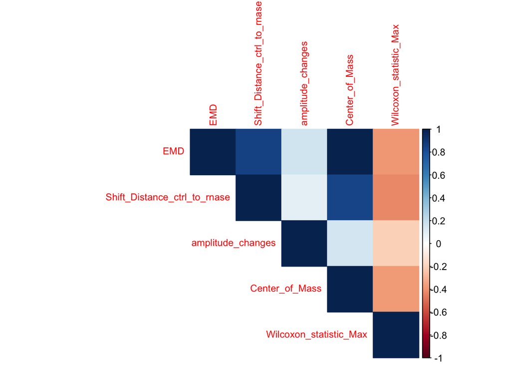

```r
# 2. Compute correlation matrix of all predictors
cor_matrix <- cor(df_all[, c("EMD", "Shift_Distance_ctrl_to_rnase",
                             "amplitude_changes", "Center_of_Mass",
                             "Wilcoxon_statistic_Max")], use = "complete.obs")

# Optional: Visualize correlations as heatmap
library(corrplot)
corrplot::corrplot(cor_matrix, method = "color", type = "upper", tl.cex = 0.8)
```

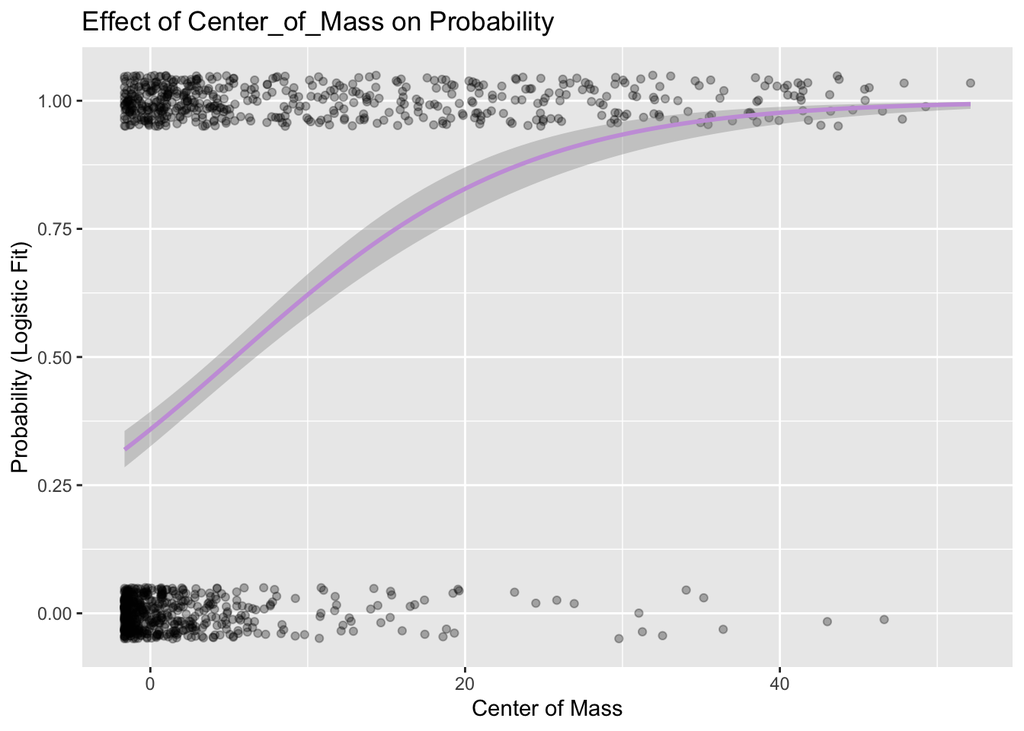

```r
# 3. Visualize the relationship between Center of Mass and the outcome variable
library(ggplot2)
ggplot(df_all, aes(x = Center_of_Mass, y = label)) +
  geom_jitter(height = 0.05, width = 0, alpha = 0.3) +
  geom_smooth(method = "glm", method.args = list(family = "binomial"), color = "#c9a0dc") +
  labs(title = "Effect of Center_of_Mass on Probability",
       x = "Center of Mass", y = "Probability (Logistic Fit)")
```

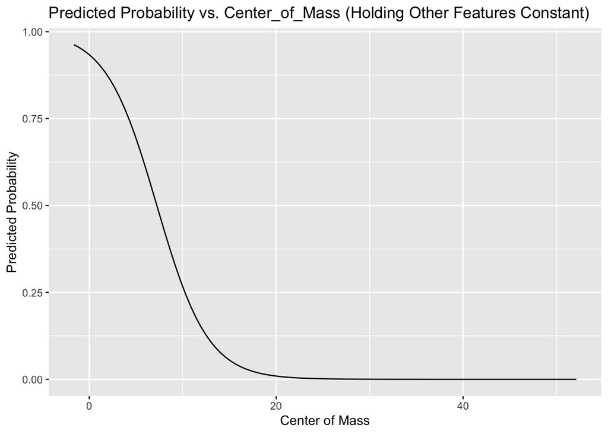

```r
# 4. Visualize isolated effect of Center_of_Mass holding other predictors constant
plot_data <- data.frame(Center_of_Mass = seq(min(df_all$Center_of_Mass, na.rm = TRUE),
                                             max(df_all$Center_of_Mass, na.rm = TRUE),
                                             length.out = 100))

# Set all other features to their mean for prediction
for (feature in setdiff(names(coef(step_model))[-1], "Center_of_Mass")) {
  plot_data[[feature]] <- mean(df_all[[feature]], na.rm = TRUE)
}

# Predict probabilities
plot_data$predicted_prob <- predict(step_model, newdata = plot_data, type = "response")

# Plot predicted probabilities
ggplot(plot_data, aes(x = Center_of_Mass, y = predicted_prob)) +
  geom_line(color = "black") +
  labs(title = "Predicted Probability vs. Center_of_Mass (Holding Other Features Constant)",
       x = "Center of Mass", y = "Predicted Probability")
```

```r
# 5. Optional: Fit a model using Center_of_Mass alone
single_model <- glm(label ~ Center_of_Mass, data = df_all, family = binomial)
summary(single_model)
```

```
##
## Call:
## glm(formula = label ~ Center_of_Mass, family = binomial, data = df_all)
##
## Coefficients:
##                 Estimate Std. Error z value Pr(>|z|)
## (Intercept)    -0.580896   0.075179  -7.727  1.1e-14 ***
## Center_of_Mass  0.107713   0.009434  11.417  < 2e-16 ***
## ---
## Signif. codes:  0 '***' 0.001 '**' 0.01 '*' 0.05 '.' 0.1 ' ' 1
##
## (Dispersion parameter for binomial family taken to be 1)
##
##     Null deviance: 1524.9  on 1099  degrees of freedom
## Residual deviance: 1299.6  on 1098  degrees of freedom
## AIC: 1303.6
##
## Number of Fisher Scoring iterations: 5
```

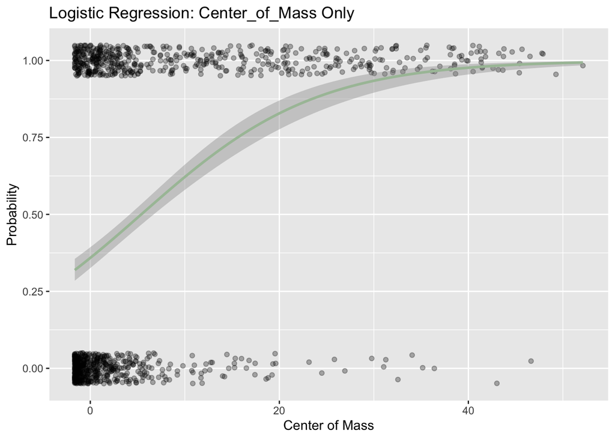

```r
# Visualization: Simple logistic regression with only Center_of_Mass
ggplot(df_all, aes(x = Center_of_Mass, y = label)) +
  geom_jitter(height = 0.05, width = 0, alpha = 0.3) +
  geom_smooth(method = "glm", method.args = list(family = "binomial"), color = "#A9C1A6") +
  labs(title = "Logistic Regression: Center_of_Mass Only",
       x = "Center of Mass", y = "Probability")
```

Output: Center_of_Mass positively correlates with the outcome on its own but shows a negative association when controlling for other variables, likely due to correlations among predictors influencing the direction of its effect. #### Modeling and Visualizing the Effect of PC1 on Outcome Using a Reduced Logistic Regression Goal: Standardize selected predictors, fit a logistic regression with less correlated variables including PC1, and visualize how predicted probabilities change with PC1 while holding other predictors constant.

```r
# 1. Standardize (scale) two predictors
df_all$amplitude_changes_z <- as.numeric(scale(df_all$amplitude_changes))
df_all$Wilcoxon_statistic_Max_z <- as.numeric(scale(df_all$Wilcoxon_statistic_Max))

# 2. Reduced logistic regression model with less correlated predictors
pca_result <- prcomp(df_all[, c("amplitude_changes_z", "Wilcoxon_statistic_Max_z")], center = TRUE, scale. = TRUE)
df_all$PC1 <- pca_result$x[, 1]

clean_model <- glm(label ~ PC1 + amplitude_changes_z + Wilcoxon_statistic_Max_z,
                   data = df_all,
                   family = binomial)

# 3. Display model summary
summary(clean_model)
```

```
##
## Call:
## glm(formula = label ~ PC1 + amplitude_changes_z + Wilcoxon_statistic_Max_z,
##     family = binomial, data = df_all)
##
## Coefficients: (1 not defined because of singularities)
##                          Estimate Std. Error z value Pr(>|z|)
## (Intercept)               0.14480    0.07329   1.976   0.0482 *
## PC1                       0.57314    0.09638   5.947 2.74e-09 ***
## amplitude_changes_z       0.79712    0.15748   5.062 4.16e-07 ***
## Wilcoxon_statistic_Max_z       NA         NA      NA       NA
## ---
## Signif. codes:  0 '***' 0.001 '**' 0.01 '*' 0.05 '.' 0.1 ' ' 1
##
## (Dispersion parameter for binomial family taken to be 1)
##
##     Null deviance: 1524.9  on 1099  degrees of freedom
## Residual deviance: 1296.6  on 1097  degrees of freedom
## AIC: 1302.6
##
## Number of Fisher Scoring iterations: 5
```

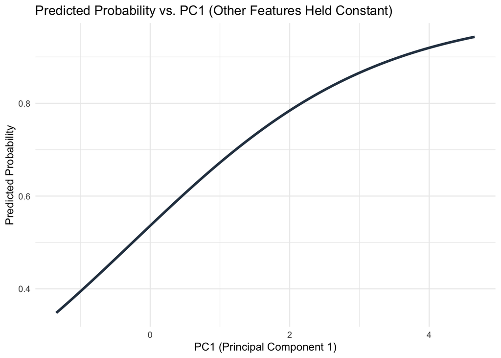

```r
# 4. Generate prediction data (vary PC1, keep other variables constant)
plot_data <- data.frame(
  PC1 = seq(min(df_all$PC1, na.rm = TRUE), max(df_all$PC1, na.rm = TRUE), length.out = 100),
  amplitude_changes_z = mean(df_all$amplitude_changes_z, na.rm = TRUE),
  Wilcoxon_statistic_Max_z = mean(df_all$Wilcoxon_statistic_Max_z, na.rm = TRUE)
)

# 5. Predict probabilities
plot_data$predicted_prob <- predict(clean_model, newdata = plot_data, type = "response")
# 6. Visualize prediction curve
library(ggplot2)
ggplot(plot_data, aes(x = PC1, y = predicted_prob)) +
  geom_line(color = "#2C3E50", size = 1.2) +
  labs(title = "Predicted Probability vs. PC1 (Other Features Held Constant)",
       x = "PC1 (Principal Component 1)",
       y = "Predicted Probability") +
  theme_minimal()
```

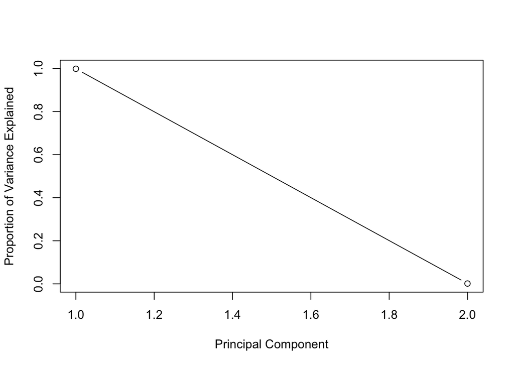

```r
# Perform PCA using only Center_of_Mass and EMD (scaled)
pca_result <- prcomp(df_all[, c("Center_of_Mass", "EMD")], scale. = TRUE)

# Extract loadings (weights of original variables on PC1 and PC2)
loadings <- pca_result$rotation

# Calculate proportion of variance explained by each principal component
var_explained <- pca_result$sdev^2 / sum(pca_result$sdev^2)

# Optional: Plot scree plot to visualize variance explained
plot(var_explained, type = "b", xlab = "Principal Component", ylab = "Proportion of Variance Explained")
```

```r
# Print example interpretation
cat("PC1 explains", round(var_explained[1] * 100, 2), "% of variance.\n")
```

```
## PC1 explains 99.86 % of variance.
```

```r
cat("Loadings for PC1:\n")
```

```
## Loadings for PC1:
```

```r
# 1. Add labels
df_positive_control$label <- 1
df_negative_control$label <- 0

# 2. Combine datasets
df_all <- rbind(
  df_positive_control[, c("EMD", "Shift_Distance_ctrl_to_rnase", "amplitude_changes", "Center_of_Mass", "Wilcoxon_statistic_Max", "label")],
  df_negative_control[, c("EMD", "Shift_Distance_ctrl_to_rnase", "amplitude_changes", "Center_of_Mass", "Wilcoxon_statistic_Max", "label")]
)

# 3. Check for NAs in PCA variables and remove if necessary
pca_vars <- df_all[, c("Center_of_Mass", "EMD")]
complete_cases <- complete.cases(pca_vars)
pca_vars_clean <- pca_vars[complete_cases, ]

# 4. Perform PCA (scale variables to make COM and EMD comparable)
pca_result <- prcomp(pca_vars_clean, scale. = TRUE)

# 5. Insert PC1 scores back into full df_all (NA for missing cases)
df_all$PC1 <- NA
df_all$PC1[complete_cases] <- pca_result$x[, 1]

# 6. Full model with PC1 (replacing EMD & COM), others remain the same
full_model_pca <- glm(label ~ PC1 + Shift_Distance_ctrl_to_rnase + amplitude_changes + Wilcoxon_statistic_Max,
                      data = df_all,
                      family = binomial)

# 7. Stepwise model selection based on AIC
step_model_pca <- step(full_model_pca, direction = "both", trace = FALSE)

# 8. Summary of the final model
summary(step_model_pca)
```

```
##
## Call:
## glm(formula = label ~ PC1 + amplitude_changes + Wilcoxon_statistic_Max,
##     family = binomial, data = df_all)
##
## Coefficients:
##                         Estimate Std. Error z value Pr(>|z|)
## (Intercept)            -0.430182   0.122568  -3.510 0.000449 ***
## PC1                     0.701806   0.076912   9.125  < 2e-16 ***
## amplitude_changes       0.455141   0.059612   7.635 2.26e-14 ***
## Wilcoxon_statistic_Max -0.019455   0.009216  -2.111 0.034760 *
## ---
## Signif. codes:  0 '***' 0.001 '**' 0.01 '*' 0.05 '.' 0.1 ' ' 1
##
## (Dispersion parameter for binomial family taken to be 1)
##
##     Null deviance: 1524.9  on 1099  degrees of freedom
## Residual deviance: 1177.9  on 1096  degrees of freedom
## AIC: 1185.9
##
## Number of Fisher Scoring iterations: 5
```

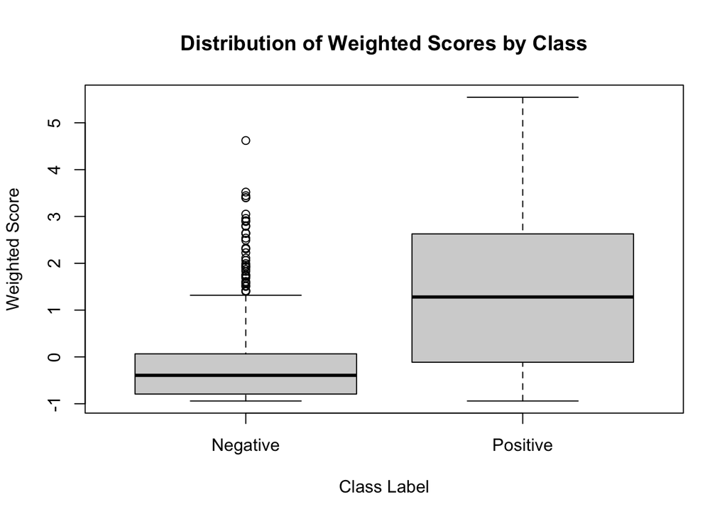

```r
# 9. Calculate weighted scores (selected features × coefficients)
coeffs <- coef(step_model_pca)[-1]  # exclude intercept
selected_features <- names(coeffs)
df_all$weighted_score <- rowSums(sweep(df_all[, selected_features], 2, coeffs, FUN = "*"), na.rm = TRUE)

# 10. Boxplot of weighted scores by class
boxplot(weighted_score ~ label, data = df_all,
        names = c("Negative", "Positive"),
        xlab = "Class Label", ylab = "Weighted Score",
        main = "Distribution of Weighted Scores by Class")
```

Output: PC1 and amplitude_changes have strong positive effects on the probability of the positive class, both highly significant. Wilcoxon_statistic_Max has a small but significant negative effect. The residual deviance (1177.9) and AIC (1185.9) suggest a good model fit, though not optimal compared to alternative models. #### Plotting Feature Importance from Logistic Regression Model Coefficients Goal: Verify that the model is a logistic regression with a binomial family, extract and rank the model coefficients by absolute value (excluding intercept), and visualize feature importance as a horizontal bar plot colored by coefficient sign.

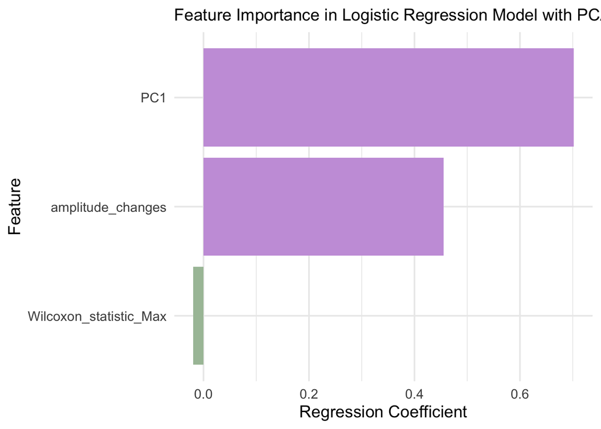

```r
# Check if step_model_pca is a logistic regression model with binomial family
if (inherits(step_model_pca, "glm") && family(step_model_pca)$family == "binomial") {

  # Extract coefficients (remove intercept)
  coeffs <- coef(step_model_pca)
  coeffs <- coeffs[-1]

  # Create dataframe for plotting
  df_coeffs <- data.frame(
    Feature = names(coeffs),
    Coefficient = coeffs,
    Importance = abs(coeffs)
  )

  # Optional: Sort by importance descending
  df_coeffs <- df_coeffs[order(-df_coeffs$Importance), ]

  # Plot using ggplot2
  library(ggplot2)
  ggplot(df_coeffs, aes(x = reorder(Feature, Importance), y = Coefficient, fill = Coefficient > 0)) +
    geom_col() +
    coord_flip() +  # horizontal bars
    scale_fill_manual(values = c("TRUE" = "#c9a0dc", "FALSE" = "#A9C1A6"), guide = "none") +
    labs(
      subtitle = "Feature Importance in Logistic Regression Model with PCA",
      x = "Feature",
      y = "Regression Coefficient"
    ) +
    theme_minimal(base_size = 14)

} else {
  stop("The model is not a logistic regression with binomial family.")
}
```

#### Model Comparison: Original vs. PCA-Based Logistic Regression Using Deviance, AIC, and Likelihood-Ratio Test Goal: Compare the predictive performance and parsimony of two logistic regression models—one using original features and the other incorporating Principal Component Analysis (PCA)—in order to determine which model better explains the binary outcome (label).

```r
# Vergleich der Modelle: Residual Deviance und AIC
cat("Old Model (step_model):\n")
```

```
## Old Model (step_model):
```

```r
cat("Residual Deviance:", step_model$deviance, "\n")
```

```
## Residual Deviance: 1157.174
```

```r
cat("AIC:", AIC(step_model), "\n\n")
```

```
## AIC: 1167.174
```

```r
cat("New PCA Model (step_model_pca):\n")
```

```
## New PCA Model (step_model_pca):
```

```r
cat("Residual Deviance:", step_model_pca$deviance, "\n")
```

```
## Residual Deviance: 1177.854
```

```r
cat("AIC:", AIC(step_model_pca), "\n\n")
```

```
## AIC: 1185.854
```

```r
# Likelihood-Ratio-Test zum Modellvergleich
anova_result <- anova(step_model, step_model_pca, test = "Chisq")
```

## ROC Curve Visualizing test-model performance

Goal: evaluate the predictive accuracy of the logistic regression model by showing the trade-off between the true positive rate (sensitivity) and false positive rate (1 - specificity) across different classification thresholds

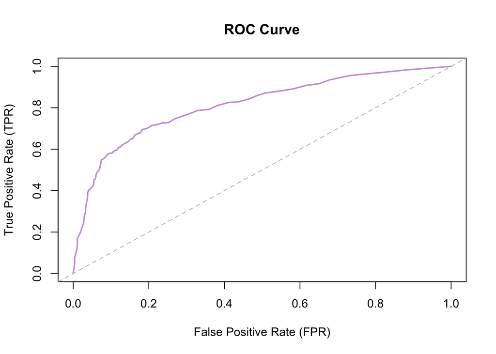

```r
# Predicted probabilities from the model (as before)
predicted_probs <- predict(logistic_model, type = "response")

# True labels
labels <- df_all$label

# Thresholds from 0 to 1 in small steps
thresholds <- seq(0, 1, by = 0.01)

# Initialize vectors for True Positive Rate (TPR) and False Positive Rate (FPR)
tpr <- numeric(length(thresholds))
fpr <- numeric(length(thresholds))

for (i in seq_along(thresholds)) {
  thresh <- thresholds[i]

  # Predictions based on the threshold
  preds <- ifelse(predicted_probs >= thresh, 1, 0)

  # Calculate True Positives, False Positives, True Negatives, False Negatives
  TP <- sum(preds == 1 & labels == 1)
  FP <- sum(preds == 1 & labels == 0)
  TN <- sum(preds == 0 & labels == 0)
  FN <- sum(preds == 0 & labels == 1)

  # Calculate TPR and FPR
  tpr[i] <- ifelse((TP + FN) == 0, 0, TP / (TP + FN))
  fpr[i] <- ifelse((FP + TN) == 0, 0, FP / (FP + TN))
}

# Define colors: lavender for ROC curve, beige for diagonal line
lavender <- "#c9a0dc"
graygreen <- "#A9C1A6"

# Plot ROC curve with lavender line
plot(fpr, tpr, type = "l", col = lavender, lwd = 2,
     xlab = "False Positive Rate (FPR)", ylab = "True Positive Rate (TPR)",
     main = "ROC Curve")

# Add diagonal line (random guess) in beige
abline(a = 0, b = 1, lty = 2, col = graygreen)
```

### test-model applied to testscores of remaining proteins

Goal: predict probability of RNA binding proteins

```r
#apply model to our data
# 1. Calculate predicted probabilities of RNA-binding using the logistic model
test_scores_combined_df$probability <- predict(logistic_model, newdata = test_scores_combined_df, type = "response")
```

#### threshold

Goal: define threshold with a 10% FDR

```r
#calculate threshold automatically
# predictions
test_scores_combined_df$predicted_prob <- predict(logistic_model, newdata = test_scores_combined_df, type = "response")

# Marks for reference
test_scores_combined_df$is_negative <- test_scores_combined_df$Protein %in% df_negative_control$Protein

# Evaluate thresholds
thresholds <- seq(0, 1, by = 0.001)
fdr_values <- sapply(thresholds, function(thresh) {
  selected <- test_scores_combined_df[test_scores_combined_df$predicted_prob > thresh, ]
  if (nrow(selected) == 0) return(NA)

  false_positives <- sum(selected$is_negative, na.rm = TRUE)
  all_positives   <- nrow(selected)
  fdr <- false_positives / all_positives
  return(fdr)
})

# Find threshold at FDR ≤ 10%
target_fdr <- 0.10
valid_thresholds <- thresholds[which(fdr_values <= target_fdr)]
optimal_threshold <- if (length(valid_thresholds) > 0) min(valid_thresholds) else NA

cat("Threshold bei FDR ≤ 10%:", optimal_threshold, "\n")
```

```
## Threshold bei FDR ≤ 10%: 0.565
```

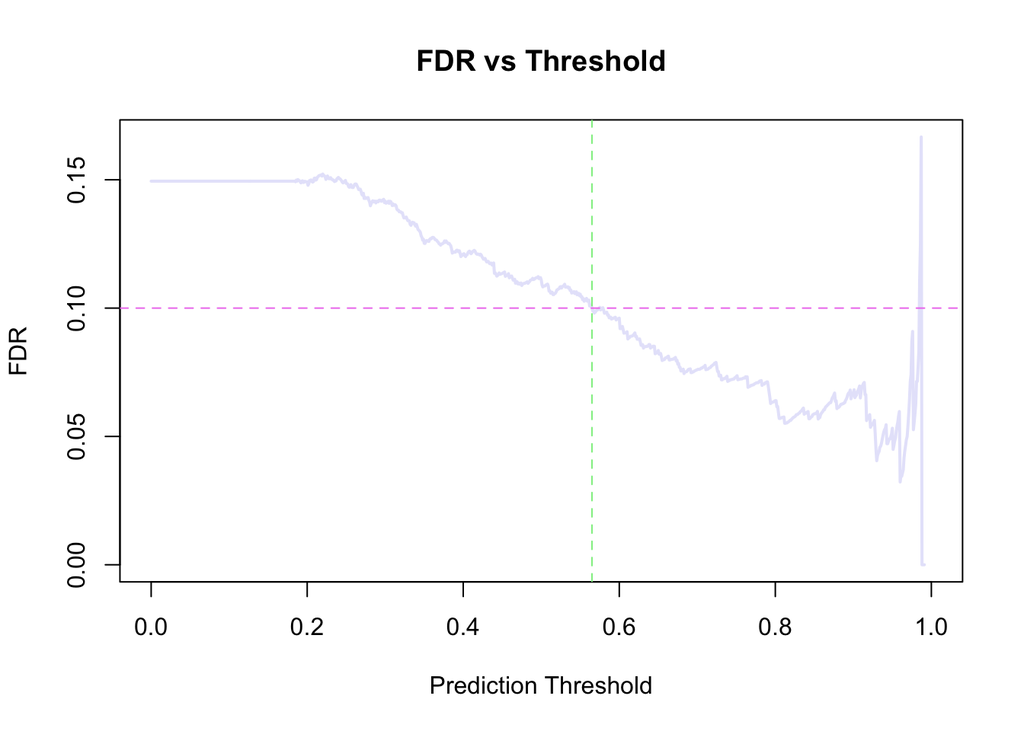

```r
#visualize FDR
plot(thresholds, fdr_values, type = "l", col = "lavender", lwd = 2,
     xlab = "Prediction Threshold", ylab = "FDR",
     main = "FDR vs Threshold")
abline(h = 0.1, col = "violet", lty = 2)
abline(v = optimal_threshold, col = "lightgreen", lty = 2)
```

```r
# Proteins with prediction scores above the optimal threshold
significant_shifted_proteins <- test_scores_combined_df[test_scores_combined_df$probability > optimal_threshold, ]

# Number of significantly shifting proteins
num_significant_shifted <- nrow(significant_shifted_proteins)

cat("Number of significantly shifted proteins:", num_significant_shifted, "\n")
```

```
## Number of significantly shifted proteins: 730
```

### overview of RBPs

- Evaluate the composition of proteins classified as RNA-binding by the logistic model: -> How many belong to the positive control set? -> many are false positives (i.e., negative control proteins)? -> How many are novel predictions outside of the control sets?

```r
#threshold is selected at FDR = 10%
# 1. Mark reference proteins in the full dataset
test_scores_combined_df$is_reference <- test_scores_combined_df$Protein %in% df_positive_control$Protein

# 2. Make predictions using the logistic model
predictions <- predict(logistic_model, newdata = test_scores_combined_df, type = "response")

# 3. Apply threshold (e.g., 0.95) to get predicted positives
selected_proteins <- test_scores_combined_df[predictions > optimal_threshold, ]
selected_proteins$is_reference <- selected_proteins$Protein %in% df_positive_control$Protein


# 4. Count how many of the selected proteins are reference proteins
ref_counts <- table(selected_proteins$is_reference)
names(ref_counts) <- c("Not positive control protein (FALSE)", "Positive Control protein (TRUE)")

#how many proteins of negative control are found at this threshold
# 1. Mark negative control proteins in the full dataset
test_scores_combined_df$is_negative <- test_scores_combined_df$Protein %in% df_negative_control$Protein

# 2. Make predictions using the existing logistic model
predictions <- predict(logistic_model, newdata = test_scores_combined_df, type = "response")

# 3. Apply threshold (z.B. gleich wie oben: 0.3899612)
selected_proteins <- test_scores_combined_df[predictions > optimal_threshold, ]

# 4. Count how many of the selected proteins are from the negative control
neg_counts <- table(selected_proteins$is_negative)
names(neg_counts) <- c("Not negative control protein (FALSE)", "Negative control protein (TRUE)")

# Extract those negative control proteins among predicted positives
predicted_negatives <- selected_proteins[selected_proteins$is_negative, ]

# Extract predicted hits that are NOT from the negative control -> TRUE: number of proteins from negative-control that are classified as shifting from the model
predicted_non_negative <- selected_proteins[!selected_proteins$is_negative, ]
```

### right shift proteins

Goal: define right shift proteins according to their delta COM

```r
# filter proteins for significant right shift with defined threshold
filtered_df <- test_scores_combined_df[
  test_scores_combined_df$Shift_direction_ctrl_to_rnase == "right shift" &
  test_scores_combined_df$probability >= optimal_threshold,
]

# Extract protein names from first column, save as dataframe
right_shift_proteins_df <- data.frame(Protein = filtered_df[[1]])

# Number of filtered proteins
right_shift_count <- nrow(filtered_df)

# Depict results
print(paste("Anzahl der 'right shift'-Proteine mit Probability ≥", optimal_threshold, ":", right_shift_count))
```

```
## [1] "Anzahl der 'right shift'-Proteine mit Probability ≥ 0.565 : 140"
```

### filter all newly identifed proteins

```r
novel_shifted_proteins <- test_scores_combined_df[
  test_scores_combined_df$probability >= optimal_threshold &
  !(test_scores_combined_df$Protein %in% df_positive_control$Protein) &
  !(test_scores_combined_df$Protein %in% df_negative_control$Protein),
]

cat("number of newly identified 'Shifted' Proteins:", nrow(novel_shifted_proteins), "\n")
```

```
## number of newly identified 'Shifted' Proteins: 311
```

### filter all newly identified right shift proteins

```r
# Right shift proteins that are in neither control group
novel_right_shift_proteins <- test_scores_combined_df[
  test_scores_combined_df$Shift_direction_ctrl_to_rnase == "right shift" &
  test_scores_combined_df$probability >= optimal_threshold &
  !(test_scores_combined_df$Protein %in% df_positive_control$Protein) &
  !(test_scores_combined_df$Protein %in% df_negative_control$Protein),
]

cat("number of newly identified 'Right Shift' Proteins:", nrow(novel_right_shift_proteins), "\n")
```

```
## number of newly identified 'Right Shift' Proteins: 58
```

# visualisation of test-model results

## composition of found RBPS

[figure not shown]

```r
# DataFrames mit Proteinnamen
total_proteins <- data.frame(Protein = test_scores_combined_df$Protein)
num_rbp <- data.frame(Protein = df_positive_control$Protein)

# Anzahl berechnen
total_count <- nrow(total_proteins)
rbp_count <- nrow(num_rbp)

# Farben
colors1 <- c("#F5E1A4","#c9a0dc")

# Matrix erstellen für Barplot
counts_matrix1 <- matrix(c(
  total_count - rbp_count,
  rbp_count
), nrow = 2, byrow = TRUE)

colnames(counts_matrix1) <- c("All Proteins")
rownames(counts_matrix1) <- c("Non-shifted", "Shifted")

# Barplot
barplot(counts_matrix1,
        beside = FALSE,
        col = colors1,
        border = "white",
        main = "All Proteins vs. Significant Shifts",
        ylab = "Number of Proteins",
        las = 1)

# Legende
legend("topright",
       legend = rownames(counts_matrix1),
       fill = colors1,
       bty = "n")
```

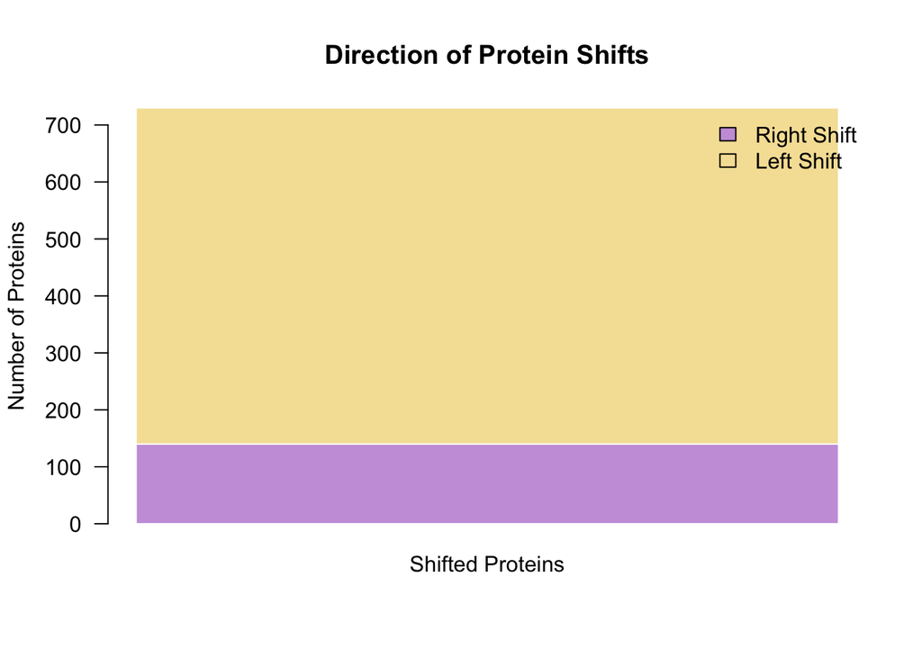

```r
# Define colors for next plot (reversed order)
colors2 <- c("#c9a0dc", "#F5E1A4")

# 2. Plot: Direction of Protein Shifts (Left vs. Right)

# define number of proteins
num_right_shift <- right_shift_count
num_left_shift <- num_significant_shifted - right_shift_count

counts_matrix2 <- matrix(c(
  num_right_shift,  # Number of proteins shifted to the right
  num_left_shift    # Number of proteins shifted to the left
), nrow = 2, byrow = TRUE)

colnames(counts_matrix2) <- c("Shifted Proteins")
rownames(counts_matrix2) <- c("Right Shift", "Left Shift")

barplot(counts_matrix2,
        beside = FALSE,
        col = colors2,
        border = "white",
        main = "Direction of Protein Shifts",
        ylab = "Number of Proteins",
        las = 1,
        ylim = c(0, num_significant_shifted))

legend("topright",
       legend = rownames(counts_matrix2),
       fill = colors2,
       bty = "n")
```

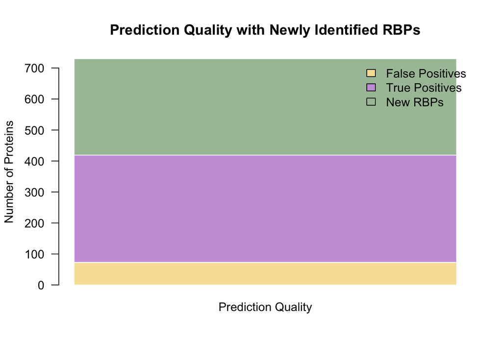

```r
# Colors: True Positives purple, False Positives beige, Newly Identified RBPs gray-green
colors3 <- c("Beige" = "#F5E1A4", "True Positives" = "#c9a0dc", "New RBPs" = "#A9C1A6")

# Number of each group
false_positives_num <- sum(predicted_negatives == "TRUE")  # Number of False Positives
true_positives_num <- sum(predicted_non_negative == "TRUE") # Number of True Positives

# Total number of predicted proteins (example)
total_predicted_proteins <- num_significant_shifted  # Or another appropriate number

# Number of newly identified RBPs
new_rbps_num <- total_predicted_proteins - (false_positives_num + true_positives_num)
if (new_rbps_num < 0) new_rbps_num <- 0  # Safety check

# Matrix for barplot: order = False Positives, True Positives, New RBPs
counts_matrix3 <- matrix(c(false_positives_num, true_positives_num, new_rbps_num),
                         nrow = 3, byrow = TRUE)

colnames(counts_matrix3) <- c("Prediction Quality")
rownames(counts_matrix3) <- c("False Positives", "True Positives", "New RBPs")

# Create barplot
barplot(counts_matrix3,
        beside = FALSE,
        col = colors3,
        border = "white",
        main = "Prediction Quality with Newly Identified RBPs",
        ylab = "Number of Proteins",
        las = 1,
        ylim = c(0, total_predicted_proteins))

# Add legend
legend("topright",
       legend = rownames(counts_matrix3),
       fill = colors3,
       bty = "n")
```

### visualization of shift direction

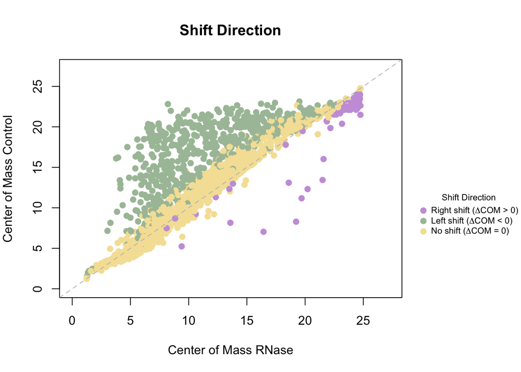

```r
# Join dataframes including global maxima and calculate their differences
df_diff_peaks <- center_of_mass_df[, 2:6]

df_diff_peaks$diff <- center_of_mass_df$Delta_COM

# calculate limits for axes
max_val <- max(
  df_diff_peaks$COM_Control,
  df_diff_peaks$COM_RNase_Control,
  na.rm = TRUE
) * 1.1

colors <- ifelse(df_diff_peaks$diff > 0 & test_scores_combined_df$probability > optimal_threshold, "#c9a0dc",      # right shift
                 ifelse(df_diff_peaks$diff < 0 & test_scores_combined_df$probability > optimal_threshold, "#A9C1A6", # left shift
                        "#F5E1A4"))   # no shift




# Set layout for plot and separate legend area
layout(matrix(1:2, nrow = 1), widths = c(4, 1))

# Plot margins
par(mar = c(5, 4, 4, 1))  # Bottom, left, top, right

# Plot the scatterplot
plot(
  df_diff_peaks$COM_RNase,
  df_diff_peaks$COM_Control,
  xlim = c(0, max_val),
  ylim = c(0, max_val),
  xlab = "Center of Mass RNase",
  ylab = "Center of Mass Control",
  main = "Shift Direction",
  pch = 19,
  col = colors
)

# Reference line y = x
abline(a = 0, b = 1, col = "grey", lty = 2)

# Switch to legend area (right panel)
par(mar = c(0, 0, 4, 0))  # No axis, top margin for title

# Draw an empty plot for the legend
plot.new()

# Draw well-formatted legend with clearer colors
legend("center",
       legend = c(
         expression("Right shift ("*Delta*"COM > 0)"),
         expression("Left shift ("*Delta*"COM < 0)"),
         expression("No shift ("*Delta*"COM = 0)")
       ),
       col = c("#c9a0dc", "#A9C1A6", "#F5E1A4"),
       pch = 19,
       title = "Shift Direction",
       bty = "n",
       pt.cex = 1,
       text.col = "black",
       cex = 0.7
)
```

### visualization of shift direction of novel proteins

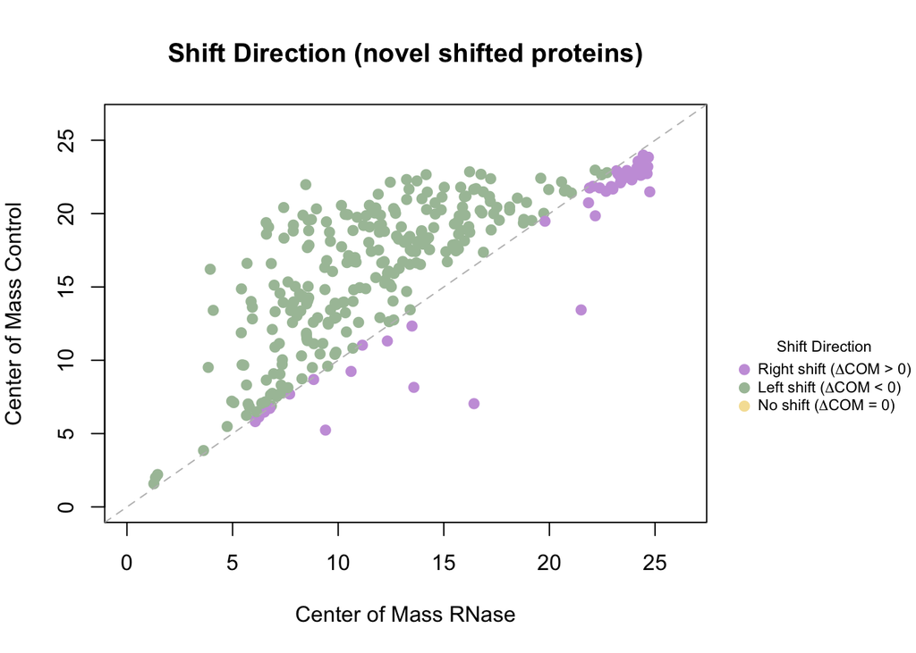

```r
# Filter the data to only include proteins in novel_shifted_proteins
selected_indices <- center_of_mass_df[[1]] %in% novel_shifted_proteins$Protein

# Subset relevant data
df_diff_peaks <- center_of_mass_df[selected_indices, 2:6]
df_diff_peaks$diff <- center_of_mass_df$Delta_COM[selected_indices]

# Subset probability values
probabilities <- test_scores_combined_df$probability[selected_indices]

# calculate limits for axes
max_val <- max(
  df_diff_peaks$COM_Control,
  df_diff_peaks$COM_RNase_Control,
  na.rm = TRUE
) * 1.1

# assign colors based on diff direction and probability
colors <- ifelse(df_diff_peaks$diff > 0 & probabilities > optimal_threshold, "#c9a0dc",      # right shift
                 ifelse(df_diff_peaks$diff < 0 & probabilities > optimal_threshold, "#A9C1A6", # left shift
                        "#F5E1A4"))   # no shift

# Set layout for plot and separate legend area
layout(matrix(1:2, nrow = 1), widths = c(4, 1))

# Plot margins
par(mar = c(5, 4, 4, 1))  # Bottom, left, top, right

# Plot the scatterplot
plot(
  df_diff_peaks$COM_RNase,
  df_diff_peaks$COM_Control,
  xlim = c(0, max_val),
  ylim = c(0, max_val),
  xlab = "Center of Mass RNase",
  ylab = "Center of Mass Control",
  main = "Shift Direction (novel shifted proteins)",
  pch = 19,
  col = colors
)

# Reference line y = x
abline(a = 0, b = 1, col = "grey", lty = 2)

# Switch to legend area (right panel)
par(mar = c(0, 0, 4, 0))  # No axis, top margin for title

# Draw an empty plot for the legend
plot.new()

# Draw legend
legend("center",
       legend = c(
         expression("Right shift ("*Delta*"COM > 0)"),
         expression("Left shift ("*Delta*"COM < 0)"),
         expression("No shift ("*Delta*"COM = 0)")
       ),
       col = c("#c9a0dc", "#A9C1A6", "#F5E1A4"),
       pch = 19,
       title = "Shift Direction",
       bty = "n",
       pt.cex = 1,
       text.col = "black",
       cex = 0.7
)
```

## show result for any desired protein

Enter a protein name to visualize its distribution across conditions (Control and RNase). The code will also return the predicted probability of RNA-binding and the corresponding classification as either RBP or Non-RBP

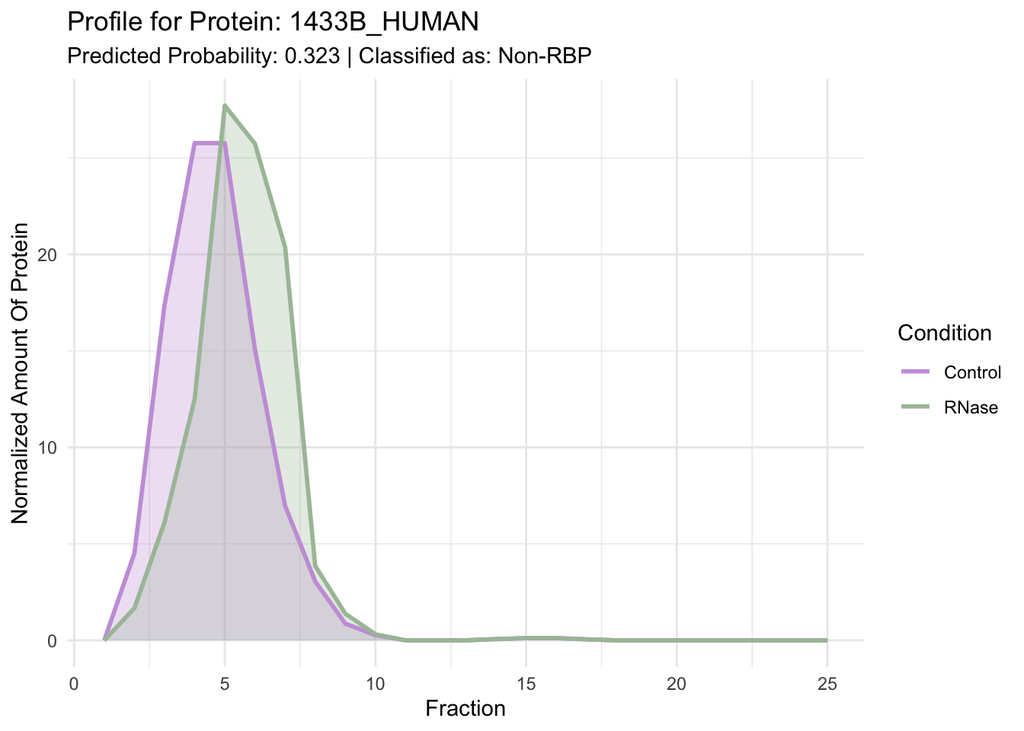

```r
# Define protein name
protein_name <- "1433B_HUMAN"

# Check if protein exists in both datasets (columns 1 to 26 only)
subset_ctrl <- normalized_ctrl_df[,1:26]
subset_rnase <- normalized_rnase_df[,1:26]

if (!(protein_name %in% subset_ctrl$Protein) |
    !(protein_name %in% subset_rnase$Protein)) {
  stop("Protein not found in one or both datasets (rows 1 to 26).")
}

# Extract only data for the given protein from rows 1–26
ctrl_data <- subset_ctrl[subset_ctrl$Protein == protein_name, ]
rnase_data <- subset_rnase[subset_rnase$Protein == protein_name, ]

# Add condition labels
ctrl_data$Condition <- "Control"
rnase_data$Condition <- "RNase"

# Combine both into one data frame for plotting
combined_df <- rbind(ctrl_data, rnase_data)

# Get probability and RBP classification
prob <- test_scores_combined_df$probability[test_scores_combined_df$Protein == protein_name]
is_rbp <- ifelse(prob > optimal_threshold, "RBP", "Non-RBP")

library(tidyr)
library(ggplot2)
library(dplyr)

# Pivot from wide to long format (gather Fraction1 to Fraction26)
long_df <- pivot_longer(
  combined_df,
  cols = starts_with("Fraction"),
  names_to = "Fraction",
  values_to = "Intensity"
)

# Convert Fraction names to numeric (e.g., "Fraction1" -> 1)
long_df$Fraction <- as.numeric(gsub("Fraction", "", long_df$Fraction))

# Get predicted probability and classification
prob <- test_scores_combined_df$probability[test_scores_combined_df$Protein == protein_name]
is_rbp <- ifelse(prob > optimal_threshold, "RBP", "Non-RBP")

#Plot
ggplot(long_df, aes(x = Fraction, y = Intensity, color = Condition, fill = Condition)) +
  # Fläche unter der Kurve einfärben (aber nicht in der Legende anzeigen)
  geom_area(alpha = 0.3, position = "identity", show.legend = FALSE) +
  # Linie zeichnen (erscheint in der Legende)
  geom_line(linewidth = 1) +
  # Farben manuell setzen
  scale_color_manual(values = c("Control" = "#c9a0dc", "RNase" = "#A9C1A6")) +
  scale_fill_manual(values = c("Control" = "#c9a0dc", "RNase" = "#A9C1A6")) +
  labs(
    title = paste("Profile for Protein:", protein_name),
    subtitle = paste0("Predicted Probability: ", round(prob, 3),
                      " | Classified as: ", is_rbp),
    x = "Fraction",
    y = "Normalized Amount Of Protein",
    color = "Condition"  # Legend title
  ) +
  theme_minimal()
```

`{r}# install.packages("shiny")` # ‘app’ panel: Protein Profile Viewer more userfriendly way to depict results: distributions, probability and classification be mindful: this chunk has to be closed or newly opened window has to be closed for following chunks to run

```r
# load libraries
library(shiny)
```

```r
library(ggplot2)
library(dplyr)
library(tidyr)

# Define User Interface
ui <- fluidPage(
  titlePanel("Protein Profile Viewer"),
  sidebarLayout(
    sidebarPanel(
      textInput("protein_name", "Enter Protein Name:", ""),
      actionButton("plot_button", "Plot")
    ),
    mainPanel(
      plotOutput("proteinPlot")
    )
  )
)

# Define Server logic
server <- function(input, output, session) {

  observeEvent(input$plot_button, {
    protein_name <- input$protein_name

    if (!exists("normalized_ctrl_df") || !exists("normalized_rnase_df") ||
    !exists("test_scores_combined_df") || !exists("optimal_threshold")) {
  output$proteinPlot <- renderPlot(NULL)
  showNotification("One or more required data objects are missing.", type = "error")
  return()
}

    # Select columns 1 (name) and 2:26 (Fraction1 to Fraction25)
    ctrl <- normalized_ctrl_df[, c(1, 2:26)]
    rnase <- normalized_rnase_df[, c(1, 2:26)]

    # Filter for selected protein
    ctrl_data <- ctrl %>% filter(Protein == protein_name)
    rnase_data <- rnase %>% filter(Protein == protein_name)

    # Check if required data objects are available
    if (!exists("normalized_ctrl_df") ||
        !exists("normalized_rnase_df") ||
        !exists("test_scores_combined_df") ||
        !exists("optimal_threshold")) {

      output$proteinPlot <- renderPlot(NULL)
      showNotification("One or more required data objects are missing.", type = "error")
      return()
    }

    # Label condition
    ctrl_data$Condition <- "Control"
    rnase_data$Condition <- "RNase"

    # Combine and reshape
    combined <- bind_rows(ctrl_data, rnase_data)
    long_df <- combined %>%
      pivot_longer(cols = starts_with("Fraction"),
                   names_to = "Fraction", values_to = "Intensity") %>%
      mutate(Fraction = as.numeric(gsub("Fraction", "", Fraction)))

    # Get model probability and RBP classification
    prob <- test_scores_combined_df$probability[test_scores_combined_df$Protein == protein_name]
    if (length(prob) == 0) prob <- NA
    classification <- ifelse(!is.na(prob) & prob > optimal_threshold, "RBP", "Non-RBP")

    output$proteinPlot <- renderPlot({
      ggplot(long_df, aes(x = Fraction, y = Intensity, color = Condition, fill = Condition)) +
        geom_area(alpha = 0.3, position = "identity", show.legend = FALSE) +
        geom_line(linewidth = 1) +
        scale_color_manual(values = c("Control" = "#c9a0dc", "RNase" = "#A9C1A6")) +
        scale_fill_manual(values = c("Control" = "#c9a0dc", "RNase" = "#A9C1A6")) +
        scale_x_continuous(breaks = seq(5, 25, by = 5), limits = c(1, 25)) +
        labs(
          title = paste("Profile for Protein:", protein_name),
          subtitle = paste0("Predicted Probability: ", round(prob, 3),
                            " | Classified as: ", classification),
          x = "Fraction",
          y = "Normalized Intensity",
          color = "Condition"
        ) +
        theme_minimal() +
        theme(panel.grid.major.x = element_blank(),
              panel.grid.minor.x = element_blank())
    })
  })
}

shinyApp(ui, server)
```

Shiny applications not supported in static R Markdown documents

#### violinplots

Goal: show the distribution of the protein in direct comparison

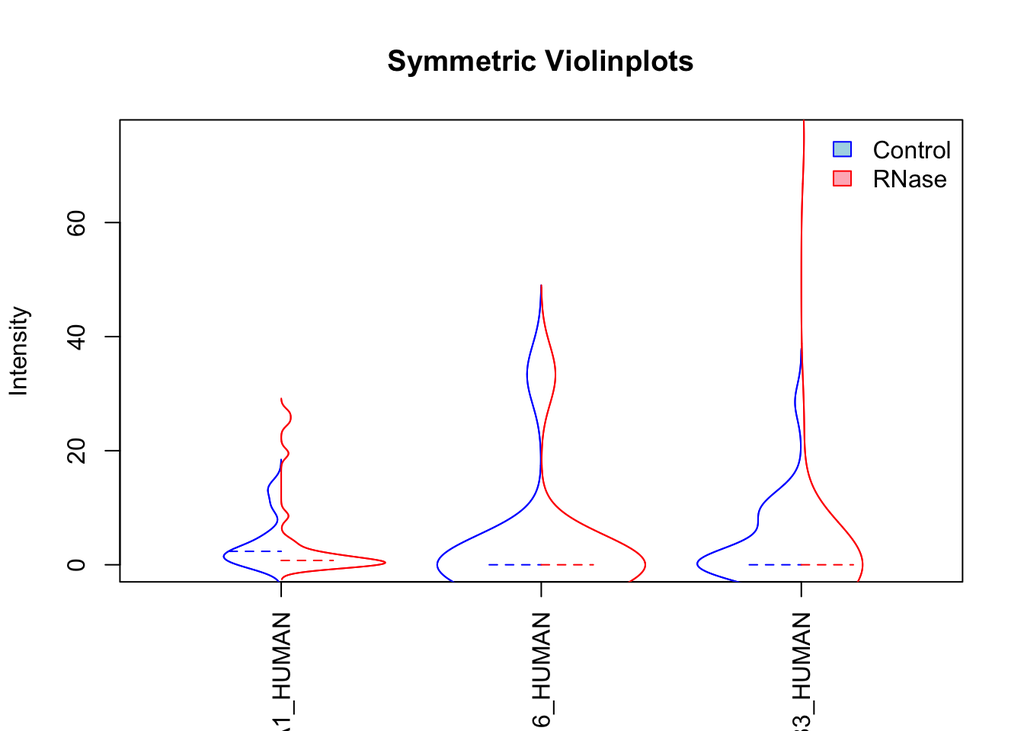

```r
# visualize the shift/non-shift of three selected proteins as violinplot
proteins <- c("RLA1_HUMAN", "APC16_HUMAN", "CH033_HUMAN")

# Plotpreperation
n <- length(proteins)
x_positions <- seq(1, by = 1, length.out = n)

# Y-axes
all_values <- c()
for (p in proteins) {
  v1 <- as.numeric(normalized_ctrl_df[normalized_ctrl_df[[1]] == p, 2:26])
  v2 <- as.numeric(normalized_rnase_df[normalized_rnase_df[[1]] == p, 2:26])
  all_values <- c(all_values, v1, v2)
}

# Basisplot
plot(NA,
     xlim = c(0.5, n + 0.5),
     ylim = range(all_values, na.rm = TRUE),
     xaxt = "n",
     xlab = "",
     ylab = "Intensity",
     main = "Symmetric Violinplots")

axis(1, at = x_positions, labels = proteins, las = 2)

# plot
for (i in seq_along(proteins)) {
  protein <- proteins[i]
  x <- x_positions[i]

  ctrl_vals <- as.numeric(normalized_ctrl_df[normalized_ctrl_df[[1]] == protein, 2:26])
  rnase_vals <- as.numeric(normalized_rnase_df[normalized_rnase_df[[1]] == protein, 2:26])


  if (sum(!is.na(ctrl_vals)) < 2 || sum(!is.na(rnase_vals)) < 2) {
    next
  }

  # calculate density and check validity
  dens_ctrl <- tryCatch(density(ctrl_vals, na.rm = TRUE), error = function(e) NULL)
  dens_rnase <- tryCatch(density(rnase_vals, na.rm = TRUE), error = function(e) NULL)

  if (is.null(dens_ctrl) || is.null(dens_rnase)) {
    next
  }

  # check length of both x- and y-vector -> have to be the same length
  if (length(dens_ctrl$x) != length(dens_ctrl$y) || length(dens_rnase$x) != length(dens_rnase$y)) {
    next
  }

  # scaling
  max_y <- max(c(dens_ctrl$y, dens_rnase$y))
  scale_factor <- 0.4 / max_y

  # Violine: Control on left
x_left  <- x - dens_ctrl$y * scale_factor
y_vals  <- dens_ctrl$x
polygon(
  x = c(x_left, rev(x_left)),
  y = c(y_vals, rev(y_vals)),
  col = "lightblue", border = "blue"
)

# Violine: RNase on right
x_right <- x + dens_rnase$y * scale_factor
y_vals2 <- dens_rnase$x
polygon(
  x = c(x_right, rev(x_right)),
  y = c(y_vals2, rev(y_vals2)),
  col = "lightpink", border="red"
)

  # add median line
  med_ctrl <- median(ctrl_vals, na.rm = TRUE)
  med_rnase <- median(rnase_vals, na.rm = TRUE)

  lines(c(x - 0.2, x), rep(med_ctrl, 2), col = "blue", lty = 2)
  lines(c(x, x + 0.2), rep(med_rnase, 2), col = "red", lty = 2)
}

# add legend
legend("topright",
       legend = c("Control", "RNase"),
       fill = c("lightblue", "lightpink"),
       border = c("blue", "red"),
       bty="n")
```

Output: visualization of a negative control and positive control protein, as well as one newly identified as shifting

# 4. Detection of features predictive of RNA-binding (Ellionor, Laura)

# linear regression

Goal: Identify experimentally accessible predictors of RNA-binding -> establish relation between predictors and RNA-binding behavior

### connect information on protein features to proteins from dataset

### load data with protein features

-> dataframe from RBP2GO is loaded that contains information on pI, Mass in kDa and length in AA as possible predictors for RNA-binding

```r
### read Table_RBPs

# read table
raw <- readLines("data/Table_HS_RBP.txt")
# extract everything below row 7
raw_data <- raw[7:length(raw)]

# clean the table
clean_data <- gsub('\\"', '', raw_data)
writeLines(clean_data, "cleaned_table.txt")
Table_HS_RBP = read.delim("cleaned_table.txt",
                    sep = "\t",
                    header = TRUE,
                    stringsAsFactors = FALSE,
                    check.names = FALSE)
```

```r
# read Table_Non_RBP


# whole table
raw <- readLines("data/Table_HS_Non_RBP.txt")
# extract everything below row 7
raw_data <- raw[7:length(raw)]

# clean the table
clean_data <- gsub('\\"', '', raw_data)
writeLines(clean_data, "cleaned_table.txt")
Table_HS_Non_RBP = read.delim("cleaned_table.txt",
                    sep = "\t",
                    header = TRUE,
                    stringsAsFactors = FALSE,
                    check.names = FALSE)
```

```r
# check if all our proteins are included in the tables
all_proteins <- test_scores_combined_df$Protein
proteins_rbp <- Table_HS_RBP$Entry_Name
proteins_non_rbp <- Table_HS_Non_RBP$Entry_Name

is_in_rbp_or_nonrbp <- test_scores_combined_df %in% proteins_rbp | test_scores_combined_df %in% proteins_non_rbp

all(is_in_rbp_or_nonrbp)
```

```
## [1] FALSE
```

```r
# Select only relevant columns from the RBP and Non-RBP tables
rbp_subset <- Table_HS_RBP[, c("Entry_Name", "pI", "Mass_kDa" , "Length_AA")]
non_rbp_subset <- Table_HS_Non_RBP[, c("Entry_Name", "pI", "Mass_kDa", "Length_AA")]

# Combine both subsets into a single table
Table_HS_Combined <- rbind(rbp_subset, non_rbp_subset)

# Merge: Proteinname-Spalten heißen unterschiedlich -> by.x / by.y verwenden
merged_df <- merge(test_scores_combined_df, Table_HS_Combined,
                   by.x = "Protein", by.y = "Entry_Name",
                   all.x = TRUE)  # keep all entries from test_scores_combined_df
#depict result
dim(merged_df)
```

```
## [1] 3680   14
```

## determinantion of suitable predictors for multiple regression

- Independent variables should exhibit minimal correlation to avoid multicollinearity -> correlation between molecular weight, sequence length, and isoelectric point was examined

```r
# select relevant columns
df_complete <- merged_df[complete.cases(merged_df[, c("probability", "pI", "Mass_kDa")]), ]
# which parameters can be used in multiple regression: correlation between independent variables should be as low as possible

cor(df_complete$Mass_kDa, df_complete$pI, method = "pearson")
```

```
## [1] -0.167674
```

```r
cor(df_complete$Mass_kDa, df_complete$Length_AA, method = "pearson")
```

```
## [1] 0.9995817
```

```r
cor(df_complete$pI, df_complete$Length_AA, method = "pearson")
```

```
## [1] -0.166558
```

output: - there is no strong correlation between pI and mass nor between pI and length - a strong correlation was observed between molecular weight and sequence length -> since molecular weight is more readily accessible experimentally than sequence length, it was used as a predictor in the multiple regression model along with the isoelectric point (pI)

## multiple regression

goal: assess whether isoelectric point (pI) and molecular mass are reliable predictors of RNA-binding probability

```r
# multiple regression: probability ~ pI + Mass_kDa
model <- lm(probability ~ pI + Mass_kDa, data = df_complete)

summary(model)
```

```
##
## Call:
## lm(formula = probability ~ pI + Mass_kDa, data = df_complete)
##
## Residuals:
##      Min       1Q   Median       3Q      Max
## -0.37044 -0.14947 -0.06751  0.09185  0.73586
##
## Coefficients:
##              Estimate Std. Error t value Pr(>|t|)
## (Intercept) 7.417e-02  1.539e-02   4.821 1.49e-06 ***
## pI          4.349e-02  2.038e-03  21.337  < 2e-16 ***
## Mass_kDa    1.221e-04  3.933e-05   3.104  0.00192 **
## ---
## Signif. codes:  0 '***' 0.001 '**' 0.01 '*' 0.05 '.' 0.1 ' ' 1
##
## Residual standard error: 0.2167 on 3672 degrees of freedom
## Multiple R-squared:  0.1104, Adjusted R-squared:  0.1099
## F-statistic: 227.8 on 2 and 3672 DF,  p-value: < 2.2e-16
```

### visualization of multiple regression

- hyperplane depicts relation between probability and predictors according to the multiple regression model `{r}# install.packages("scatterplot3d")`

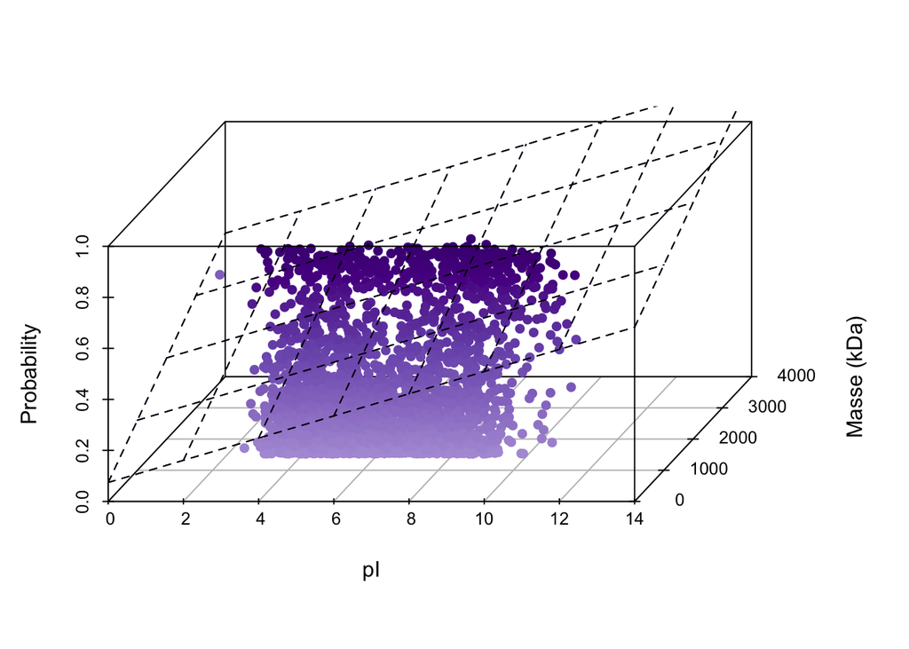

```r
# visualization of linear regression using hyperplanes
library(scatterplot3d)


depth <- df_complete$probability

# colorscheme
farben <- colorRampPalette(c("#b19cd9", "#7b59b9", "#4b0082"))(100)

color_index <- cut(depth, breaks = 100, labels = FALSE)
point_colors <- farben[color_index]

s3d <- scatterplot3d(df_complete$pI, df_complete$Mass_kDa, df_complete$probability,
                     xlab = "pI", ylab = "Masse (kDa)", zlab = "Probability",
                     pch = 16, color = point_colors,
                     highlight.3d = FALSE,
                     type = "p", angle = 55)

s3d$plane3d(model, col = "#4b0082")



# Koordinaten der Regressionsfläche berechnen
plane <- predict(model,
                 newdata = data.frame(pI = df_complete$pI,
                                      Mass_kDa = df_complete$Mass_kDa))

# Fläche einzeichnen
s3d$plane3d(model)
```

output: - The closer the points lie to the plane, the better the model fits the observed data - Large distances between the points and the plane indicate that the model explains only a small portion of the variance -> depicts that only approximately 11% of variance is explained by the model

### visualization of multiple regression

interactive hyperplane displays the same relatins as the chunk above but offers a better spacial unterstanding `{r}# install.packages("plotly")`

```r
# create interactive hyperplane
library(plotly)
# new classification
df_complete$RBP_shift_category <- ifelse(df_complete$probability >= optimal_threshold,
                                         ifelse(df_complete$Shift_direction_ctrl_to_rnase == "left shift", "RBP_left",
                                                ifelse(df_complete$Shift_direction_ctrl_to_rnase == "right shift", "RBP_right", "RBP")),
                                         "Non-RBP")


# grid for regressionplane
pI_seq <- seq(min(df_complete$pI), max(df_complete$pI), length.out = 30)
Mass_seq <- seq(min(df_complete$Mass_kDa), max(df_complete$Mass_kDa), length.out = 30)
grid <- expand.grid(pI = pI_seq, Mass_kDa = Mass_seq)
grid$predicted <- predict(model, newdata = grid)

# determine colors
farben <- list("RBP_left" = "#c9a0dc",     # hell-lila
               "RBP_right" = "#7a42a6",    # dunkel-lila
               "RBP" = "purple",
               "Non-RBP" = "lightgray")

# Plotly Plot
fig <- plot_ly()

# RBP_left
fig <- fig %>%
  add_markers(data = subset(df_complete, RBP_shift_category == "RBP_left"),
              x = ~pI, y = ~Mass_kDa, z = ~probability,
              marker = list(color = farben[["RBP_left"]], size = 4),
              name = "RBP (left shift)")

# RBP_right
fig <- fig %>%
  add_markers(data = subset(df_complete, RBP_shift_category == "RBP_right"),
              x = ~pI, y = ~Mass_kDa, z = ~probability,
              marker = list(color = farben[["RBP_right"]], size = 4),
              name = "RBP (right shift)")

# RBP without Shift-Direction
fig <- fig %>%
  add_markers(data = subset(df_complete, RBP_shift_category == "RBP"),
              x = ~pI, y = ~Mass_kDa, z = ~probability,
              marker = list(color = farben[["RBP"]], size = 4),
              name = "RBP (no shift info)")

# Non-RBP
fig <- fig %>%
  add_markers(data = subset(df_complete, RBP_shift_category == "Non-RBP"),
              x = ~pI, y = ~Mass_kDa, z = ~probability,
              marker = list(color = farben[["Non-RBP"]], size = 4),
              name = "Non-RBP")

# Regressionplane
fig <- fig %>%
  add_surface(x = ~pI_seq,
              y = ~Mass_seq,
              z = matrix(grid$predicted, nrow = 30),
              opacity = 0.5,
              colorscale = "Purples",
              showscale = FALSE,
              name = "Regression Surface")

# Layout
fig <- fig %>%
  layout(scene = list(
    xaxis = list(title = "pI"),
    yaxis = list(title = "Mass (kDa)", tick0 = 0, dtick = 100, range = c(0, 1000)),
    zaxis = list(title = "Probability")
  ),
  legend = list(title = list(text = "<b>Protein Classification</b>")))

fig
```

[interactive chart not shown]

## check individual relation between predictors and probability

### determine whether there is a signifcant relation between a higher pI and an increased probability for RNA-binding

- using a t-test the pIs of RBPs and Non-RBPs are compared

```r
#hypothesis: proteins with a higher pI are more significantly more likely to be RBPs -> have positively charged domains at physiological pH -> are more likely to bind negatively charged RNA

# Group proteins based on optimal threshold:
df_complete$RBP_group <- ifelse(df_complete$probability > optimal_threshold,
                               "RBP", "Non-RBP")

# Optional: check mean pI values per group to confirm
aggregate(pI ~ RBP_group, data = df_complete, mean)
```

```
##   RBP_group       pI
## 1   Non-RBP 6.730949
## 2       RBP 8.069842
```

```r
# Perform one-sided Welch Two Sample t-test comparing pI of RBP vs Non-RBP
# as big sample sizes are used, it was assumed that the central limit theorem applies (meaning the data follows a normal distribution)
t_test_result <- t.test(
  df_complete$pI[df_complete$RBP_group == "RBP"],
  df_complete$pI[df_complete$RBP_group == "Non-RBP"],
  alternative = "greater"
)
```

### visualization of relation between pI and probability

```r
# create boxplot
boxplot(pI ~ RBP_group,
        data = df_complete,
        col = c("#A9C1A6", "#c9a0dc"),
        main = "compare pI\nbetween RBP and Non-RBP",
        xlab = "group",
        ylab = "isoelectric point (pI)")

# calculate mean
mean_rbp <- mean(df_complete$pI[df_complete$RBP_group == "RBP"])
mean_nonrbp <- mean(df_complete$pI[df_complete$RBP_group == "Non-RBP"])

print(mean_rbp)
```

```
## [1] 8.069842
```

```r
print(mean_nonrbp)
```

```
## [1] 6.730949
```

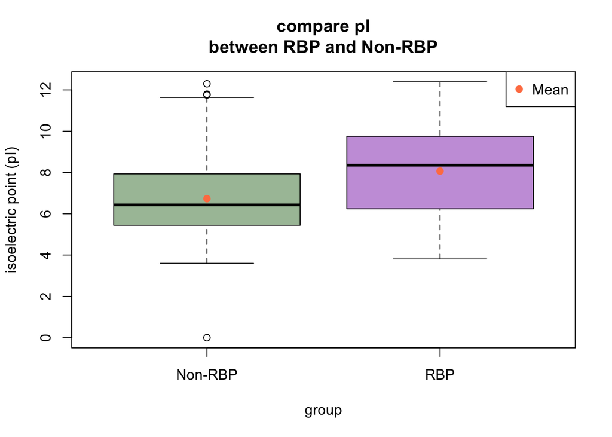

```r
# depict mean in plot
points(c(1, 2), c(mean_nonrbp, mean_rbp), pch = 19, col = "coral")

# Oadd legend
legend("topright", legend = c("Mean"), col = "coral", pch = 19)
```

### determine whether there is a signifcant relation between mass and the probability for RNA-binding - using a t-test the mass of RBPs and Non-RBPs are compared

```r
#check whether mass differs significantly between RBPs and Non-RBPs

# Perform two-sided Welch Two Sample t-test comparing pI of RBP vs Non-RBP
t_test_result <- t.test(
  df_complete$Mass_kDa[df_complete$RBP_group == "RBP"],
  df_complete$Mass_kDa[df_complete$RBP_group == "Non-RBP"],
)
```

# 5. dimension reduction (Zoe)

### PCA

Goal: Reduce dimension and further visualize data in clusters with only the most important structures. Batch cleaned data is used in order to ensure no technical variation. ##Control

#check how data set is made up, ctrl

```r
ctrl_perc_df <- as.data.frame(percent_ctrl_df[,-1])
rownames(ctrl_perc_df) <- ctrl_perc_df$X
C_test <- ctrl_perc_df

# we have 3680 observations and 75 features
```

#Test data -> check if varibales are on the same scale

```r
apply(C_test, 2, mean)
```

```
##  Fraction1_Rep1  Fraction1_Rep2  Fraction1_Rep3  Fraction2_Rep1  Fraction2_Rep2
##        420.7889        420.7889        420.7889       5176.8732       5176.8732
##  Fraction2_Rep3  Fraction3_Rep1  Fraction3_Rep2  Fraction3_Rep3  Fraction4_Rep1
##       5176.8732      10265.8447      10265.8447      10265.8447      17874.0379
##  Fraction4_Rep2  Fraction4_Rep3  Fraction5_Rep1  Fraction5_Rep2  Fraction5_Rep3
##      17874.0379      17874.0379      17388.4419      17388.4419      17388.4419
##  Fraction6_Rep1  Fraction6_Rep2  Fraction6_Rep3  Fraction7_Rep1  Fraction7_Rep2
##      17764.9658      17764.9658      17764.9658      15060.5534      15060.5534
##  Fraction7_Rep3  Fraction8_Rep1  Fraction8_Rep2  Fraction8_Rep3  Fraction9_Rep1
##      15060.5534      16102.2155      16102.2155      16102.2155      14954.6345
##  Fraction9_Rep2  Fraction9_Rep3 Fraction10_Rep1 Fraction10_Rep2 Fraction10_Rep3
##      14954.6345      14954.6345      12570.0292      12570.0292      12570.0292
## Fraction11_Rep1 Fraction11_Rep2 Fraction11_Rep3 Fraction12_Rep1 Fraction12_Rep2
##      11120.8753      11120.8753      11120.8753       8426.6284       8426.6284
## Fraction12_Rep3 Fraction13_Rep1 Fraction13_Rep2 Fraction13_Rep3 Fraction14_Rep1
##       8426.6284       7110.3168       7110.3168       7110.3168       5952.9816
## Fraction14_Rep2 Fraction14_Rep3 Fraction15_Rep1 Fraction15_Rep2 Fraction15_Rep3
##       5952.9816       5952.9816       5508.0804       5508.0804       5508.0804
## Fraction16_Rep1 Fraction16_Rep2 Fraction16_Rep3 Fraction17_Rep1 Fraction17_Rep2
##       4958.7346       4958.7346       4958.7346       5208.4004       5208.4004
## Fraction17_Rep3 Fraction18_Rep1 Fraction18_Rep2 Fraction18_Rep3 Fraction19_Rep1
##       5208.4004       5592.2627       5592.2627       5592.2627       4630.7947
## Fraction19_Rep2 Fraction19_Rep3 Fraction20_Rep1 Fraction20_Rep2 Fraction20_Rep3
##       4630.7947       4630.7947       5218.1908       5218.1908       5218.1908
## Fraction21_Rep1 Fraction21_Rep2 Fraction21_Rep3 Fraction22_Rep1 Fraction22_Rep2
##       7072.3347       7072.3347       7072.3347       9176.0772       9176.0772
## Fraction22_Rep3 Fraction23_Rep1 Fraction23_Rep2 Fraction23_Rep3 Fraction24_Rep1
##       9176.0772       7479.2061       7479.2061       7479.2061       6051.1730
## Fraction24_Rep2 Fraction24_Rep3 Fraction25_Rep1 Fraction25_Rep2 Fraction25_Rep3
##       6051.1730       6051.1730       6387.0075       6387.0075       6387.0075
```

```r
apply(C_test, 2, sd)
```

```
##  Fraction1_Rep1  Fraction1_Rep2  Fraction1_Rep3  Fraction2_Rep1  Fraction2_Rep2
##        5147.820        5510.457        5006.167       22264.697       21172.190
##  Fraction2_Rep3  Fraction3_Rep1  Fraction3_Rep2  Fraction3_Rep3  Fraction4_Rep1
##       20312.994       41460.431       39096.618       37671.865       65772.307
##  Fraction4_Rep2  Fraction4_Rep3  Fraction5_Rep1  Fraction5_Rep2  Fraction5_Rep3
##       65080.047       61381.544       63209.029       68417.633       60970.337
##  Fraction6_Rep1  Fraction6_Rep2  Fraction6_Rep3  Fraction7_Rep1  Fraction7_Rep2
##       62338.082       72015.238       62733.235       57011.757       68172.356
##  Fraction7_Rep3  Fraction8_Rep1  Fraction8_Rep2  Fraction8_Rep3  Fraction9_Rep1
##       57456.798       62186.431       67262.997       62101.438       57974.396
##  Fraction9_Rep2  Fraction9_Rep3 Fraction10_Rep1 Fraction10_Rep2 Fraction10_Rep3
##       62016.905       57165.751       45666.333       49136.883       44372.289
## Fraction11_Rep1 Fraction11_Rep2 Fraction11_Rep3 Fraction12_Rep1 Fraction12_Rep2
##       39061.593       41134.166       37829.133       30696.971       31658.480
## Fraction12_Rep3 Fraction13_Rep1 Fraction13_Rep2 Fraction13_Rep3 Fraction14_Rep1
##       28920.470       26584.258       28057.868       25884.723       22627.547
## Fraction14_Rep2 Fraction14_Rep3 Fraction15_Rep1 Fraction15_Rep2 Fraction15_Rep3
##       24829.004       22686.455       20306.698       22437.065       20900.473
## Fraction16_Rep1 Fraction16_Rep2 Fraction16_Rep3 Fraction17_Rep1 Fraction17_Rep2
##       16432.820       18239.285       17472.236       17493.427       19012.921
## Fraction17_Rep3 Fraction18_Rep1 Fraction18_Rep2 Fraction18_Rep3 Fraction19_Rep1
##       19176.917       19356.847       20973.515       21609.983       16254.836
## Fraction19_Rep2 Fraction19_Rep3 Fraction20_Rep1 Fraction20_Rep2 Fraction20_Rep3
##       17460.755       18016.217       19532.384       20841.807       20066.727
## Fraction21_Rep1 Fraction21_Rep2 Fraction21_Rep3 Fraction22_Rep1 Fraction22_Rep2
##       29156.282       31271.999       28779.407       38816.640       41274.451
## Fraction22_Rep3 Fraction23_Rep1 Fraction23_Rep2 Fraction23_Rep3 Fraction24_Rep1
##       38405.976       32224.809       33870.155       32321.331       26451.698
## Fraction24_Rep2 Fraction24_Rep3 Fraction25_Rep1 Fraction25_Rep2 Fraction25_Rep3
##       28182.661       27908.674       28646.782       31234.707       32288.892
```

-> big differences, not perfectly scaled

##pca selbst ctrl -> prcomp: uses singular value decomposition, according to r it has slightly better numerical accuracy -> center=TRUE, scale=TRUE: makes sure mean ~ 0 , sd ~ 1 -> Z-scores

```r
ctrl_pca <- prcomp(ctrl_perc_df, center = TRUE, scale = TRUE)

names(ctrl_pca)
```

```
## [1] "sdev"     "rotation" "center"   "scale"    "x"
```

```r
head(ctrl_pca$rotation[,1:6])
```

```
##                       PC1         PC2       PC3        PC4        PC5
## Fraction1_Rep1 0.01388884 -0.05782025 0.1030970 -0.1260550 -0.3788105
## Fraction1_Rep2 0.01152650 -0.05312866 0.1014550 -0.1206626 -0.3737922
## Fraction1_Rep3 0.01653639 -0.06152299 0.1063059 -0.1297864 -0.3757649
## Fraction2_Rep1 0.03770994 -0.13065822 0.1856465 -0.1650818 -0.1267249
## Fraction2_Rep2 0.03702287 -0.12946064 0.1855870 -0.1642662 -0.1359415
## Fraction2_Rep3 0.03793324 -0.13095449 0.1880789 -0.1574834 -0.1062968
##                        PC6
## Fraction1_Rep1 -0.24870822
## Fraction1_Rep2 -0.25242059
## Fraction1_Rep3 -0.24345486
## Fraction2_Rep1 -0.01467839
## Fraction2_Rep2 -0.02408832
## Fraction2_Rep3 -0.01396047
```

-> standard deviation of each principal component is saved in “sdev”, as a measure of variance -> check how much do points vary on average from the mean

```r
head(ctrl_pca$sdev)
```

```
## [1] 5.541789 4.119378 3.178150 2.576726 1.729997 1.540654
```

-> get variance by squaring the standard deviation -> check how much does the data spread out in square units

```r
ctrl_pca_var <- ctrl_pca$sdev^2 # eigenvalues
ctrl_pca_var
```

```
##  [1] 3.071142e+01 1.696927e+01 1.010064e+01 6.639515e+00 2.992890e+00
##  [6] 2.373616e+00 1.532141e+00 8.466667e-01 5.826292e-01 3.222409e-01
## [11] 3.064710e-01 2.279798e-01 2.091155e-01 1.478372e-01 1.318440e-01
## [16] 1.104395e-01 1.031939e-01 8.424696e-02 7.110598e-02 7.048462e-02
## [21] 6.601674e-02 5.141736e-02 4.249879e-02 3.793000e-02 3.168543e-02
## [26] 2.590203e-02 2.411926e-02 2.125529e-02 2.040821e-02 1.719261e-02
## [31] 1.527978e-02 1.419341e-02 1.117323e-02 9.398170e-03 8.133113e-03
## [36] 7.939844e-03 6.853943e-03 6.559834e-03 6.042916e-03 5.504993e-03
## [41] 4.977029e-03 4.715980e-03 3.800760e-03 3.477752e-03 3.017299e-03
## [46] 2.366247e-03 1.893781e-03 1.738081e-03 1.470478e-03 1.310206e-03
## [51] 1.257959e-03 1.120284e-03 7.654307e-04 7.463318e-04 5.543377e-04
## [56] 5.097887e-04 4.491931e-04 3.966736e-04 3.625047e-04 3.297102e-04
## [61] 3.046204e-04 2.752018e-04 2.027376e-04 1.850975e-04 1.648095e-04
## [66] 1.237313e-04 9.753005e-05 5.828202e-05 2.421454e-05 2.131499e-05
## [71] 1.668210e-05 1.088734e-05 1.188506e-27 3.902207e-28 1.630787e-28
```

Goal: -> control which PC explains how much variance

```r
ctrl_pca_ve <- ctrl_pca_var / sum(ctrl_pca_var)
ctrl_pca_ve_percent <- ctrl_pca_ve * 100
ctrl_pca_ve_percent
```

```
##  [1] 4.094856e+01 2.262570e+01 1.346751e+01 8.852687e+00 3.990520e+00
##  [6] 3.164821e+00 2.042854e+00 1.128889e+00 7.768390e-01 4.296546e-01
## [11] 4.086280e-01 3.039730e-01 2.788207e-01 1.971163e-01 1.757920e-01
## [16] 1.472527e-01 1.375918e-01 1.123293e-01 9.480798e-02 9.397949e-02
## [21] 8.802232e-02 6.855647e-02 5.666506e-02 5.057334e-02 4.224724e-02
## [26] 3.453604e-02 3.215901e-02 2.834038e-02 2.721095e-02 2.292348e-02
## [31] 2.037304e-02 1.892455e-02 1.489763e-02 1.253089e-02 1.084415e-02
## [36] 1.058646e-02 9.138591e-03 8.746445e-03 8.057221e-03 7.339990e-03
## [41] 6.636039e-03 6.287974e-03 5.067680e-03 4.637003e-03 4.023065e-03
## [46] 3.154997e-03 2.525042e-03 2.317441e-03 1.960637e-03 1.746941e-03
## [51] 1.677278e-03 1.493712e-03 1.020574e-03 9.951090e-04 7.391169e-04
## [56] 6.797183e-04 5.989241e-04 5.288982e-04 4.833396e-04 4.396136e-04
## [61] 4.061605e-04 3.669358e-04 2.703167e-04 2.467966e-04 2.197460e-04
## [66] 1.649750e-04 1.300401e-04 7.770936e-05 3.228606e-05 2.841998e-05
## [71] 2.224280e-05 1.451646e-05 1.584674e-27 5.202943e-28 2.174382e-28
```

-> PC1: 40.9%, PC2:22.6%, PC3:13.47%